# Data Visualization - Case Study 1 to 4

# CLASS PRACTICE 4

1. Plot the following graph (adding smooth()):

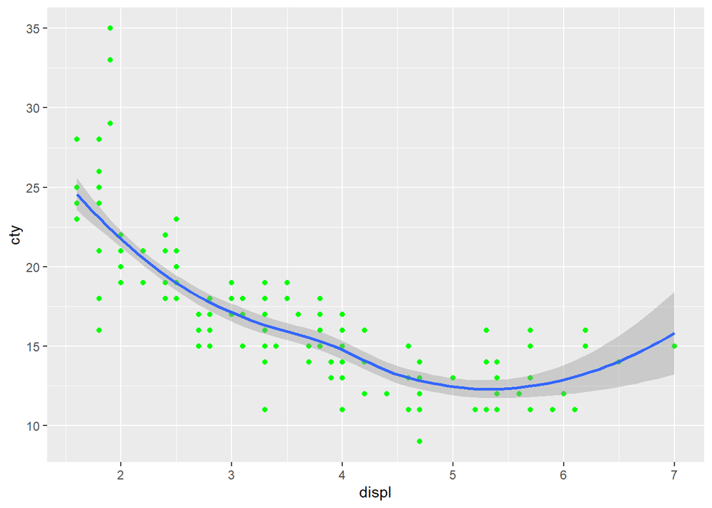

```r
ggplot(mpg, aes(x=displ, y = cty)) +
  geom_point(colour="green") +
  geom_smooth()
```

2. Change the method to linear (method=“lm”)

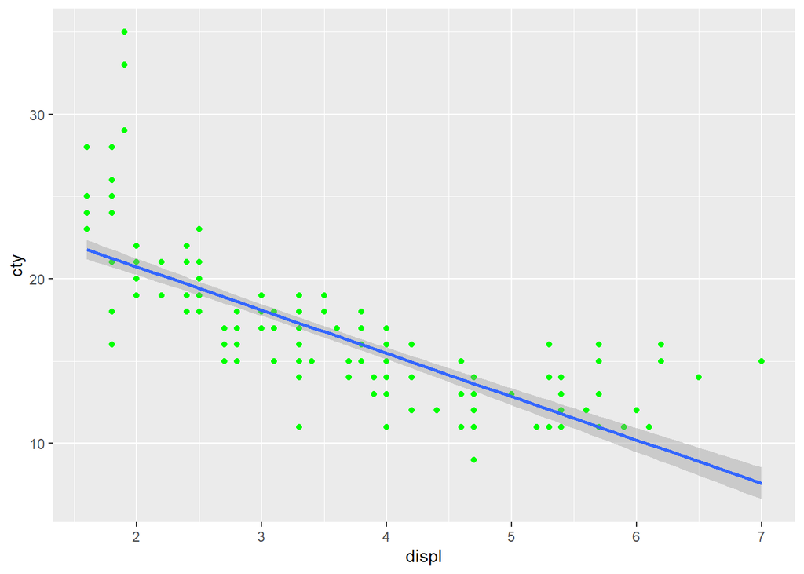

```r
ggplot(mpg, aes(x=displ, y = cty)) +
  geom_point(colour="green") +
  geom_smooth(method = "lm")
```

3. Changing the span parameter to control wiggliness of the line:

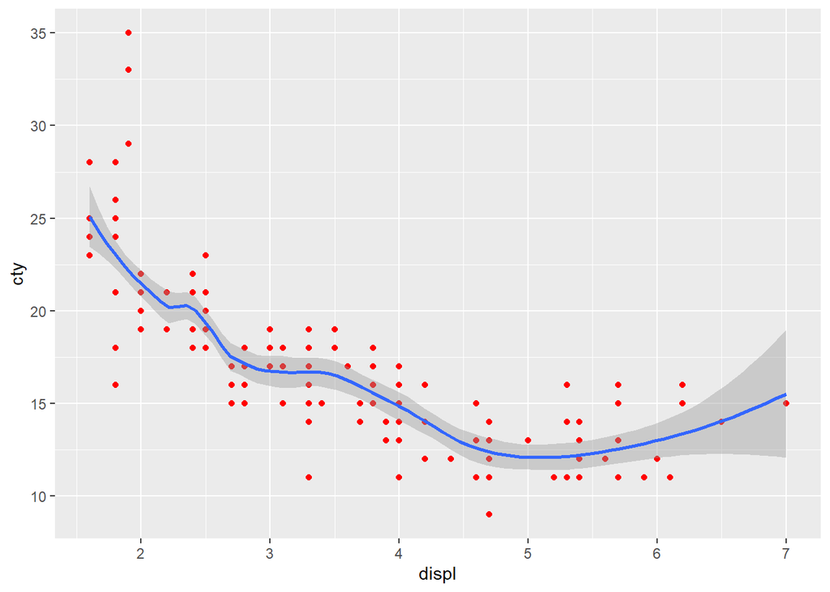

```r
ggplot(mpg, aes(x=displ, y = cty)) +
  geom_point(colour="red") +
  geom_smooth(span=0.4)
```

4. How is this smooth() function useful in interpreting results?

Answer: It can be hard to view trends with just points alone. Many times we wish to add a smoothing line in order to see what the trends look like. This can be especially helpful when trying to understand regressions. It aids the eye in seeing patterns in the presence of overplotting.

5. Can you use this to explain this to a senior management executive

Answer: The normal plot shoews the scatter plot of the data and is difficut to interpret. As a senior management the smoothened line provided by the smooth function, it is easier to get a clear picture to the data and what inference that could be taken out of it.

6. Try changing span parameter, Values range from 0 to 1

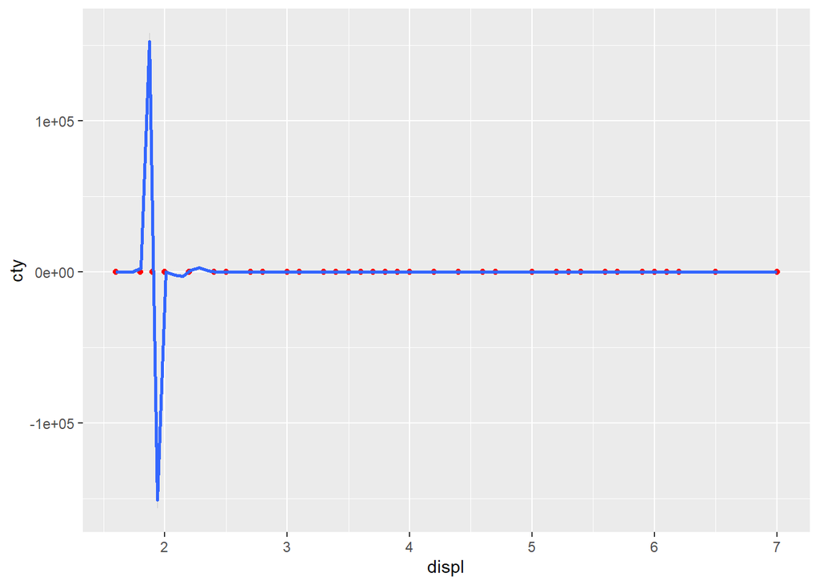

```r
ggplot(mpg, aes(x=displ, y = cty)) +
  geom_point(colour="red") +
  geom_smooth(span=0.1)
```

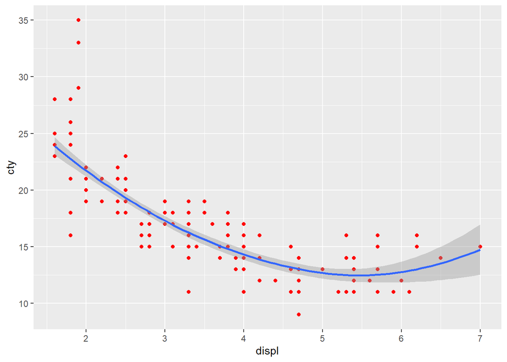

```r
ggplot(mpg, aes(x=displ, y = cty)) +
  geom_point(colour="red") +
  geom_smooth(span=1)
```

Answer: When we changed the span = 1 we can see that this is much smoother. The span can be varied from 0 to 1, where 0 is very rough and 1 is very smooth.